# 红酒数据集探索性数据分析

钱忠华

2017年10月6日

# 1.载入包

# 2.数据概况

数据集总共有12个变量，1599个样本数据。

```
## 'data.frame':    1599 obs. of  13 variables:
##  $ X                   : int  1 2 3 4 5 6 7 8 9 10 ...
##  $ fixed.acidity       : num  7.4 7.8 7.8 11.2 7.4 7.4 7.9 7.3 7.8 7.5 ...
##  $ volatile.acidity    : num  0.7 0.88 0.76 0.28 0.7 0.66 0.6 0.65 0.58 0.5 ...
##  $ citric.acid         : num  0 0 0.04 0.56 0 0 0.06 0 0.02 0.36 ...
##  $ residual.sugar      : num  1.9 2.6 2.3 1.9 1.9 1.8 1.6 1.2 2 6.1 ...
##  $ chlorides           : num  0.076 0.098 0.092 0.075 0.076 0.075 0.069 0.065 0.073 0.071 ...
##  $ free.sulfur.dioxide : num  11 25 15 17 11 13 15 15 9 17 ...
##  $ total.sulfur.dioxide: num  34 67 54 60 34 40 59 21 18 102 ...
##  $ density             : num  0.998 0.997 0.997 0.998 0.998 ...
##  $ pH                  : num  3.51 3.2 3.26 3.16 3.51 3.51 3.3 3.39 3.36 3.35 ...
##  $ sulphates           : num  0.56 0.68 0.65 0.58 0.56 0.56 0.46 0.47 0.57 0.8 ...
##  $ alcohol             : num  9.4 9.8 9.8 9.8 9.4 9.4 9.4 10 9.5 10.5 ...
##  $ quality             : int  5 5 5 6 5 5 5 7 7 5 ...
```

```
##   X fixed.acidity volatile.acidity citric.acid residual.sugar chlorides
## 1 1           7.4             0.70        0.00            1.9     0.076
## 2 2           7.8             0.88        0.00            2.6     0.098
## 3 3           7.8             0.76        0.04            2.3     0.092
## 4 4          11.2             0.28        0.56            1.9     0.075
## 5 5           7.4             0.70        0.00            1.9     0.076
## 6 6           7.4             0.66        0.00            1.8     0.075
##   free.sulfur.dioxide total.sulfur.dioxide density   pH sulphates alcohol
## 1                  11                   34  0.9978 3.51      0.56     9.4
## 2                  25                   67  0.9968 3.20      0.68     9.8
## 3                  15                   54  0.9970 3.26      0.65     9.8
## 4                  17                   60  0.9980 3.16      0.58     9.8
## 5                  11                   34  0.9978 3.51      0.56     9.4
## 6                  13                   40  0.9978 3.51      0.56     9.4
##   quality
## 1       5
## 2       5
## 3       5
## 4       6
## 5       5
## 6       5
```

查看变量的summary信息

```
##        X          fixed.acidity   volatile.acidity  citric.acid
##  Min.   :   1.0   Min.   : 4.60   Min.   :0.1200   Min.   :0.000
##  1st Qu.: 400.5   1st Qu.: 7.10   1st Qu.:0.3900   1st Qu.:0.090
##  Median : 800.0   Median : 7.90   Median :0.5200   Median :0.260
##  Mean   : 800.0   Mean   : 8.32   Mean   :0.5278   Mean   :0.271
##  3rd Qu.:1199.5   3rd Qu.: 9.20   3rd Qu.:0.6400   3rd Qu.:0.420
##  Max.   :1599.0   Max.   :15.90   Max.   :1.5800   Max.   :1.000
##  residual.sugar     chlorides       free.sulfur.dioxide
##  Min.   : 0.900   Min.   :0.01200   Min.   : 1.00
##  1st Qu.: 1.900   1st Qu.:0.07000   1st Qu.: 7.00
##  Median : 2.200   Median :0.07900   Median :14.00
##  Mean   : 2.539   Mean   :0.08747   Mean   :15.87
##  3rd Qu.: 2.600   3rd Qu.:0.09000   3rd Qu.:21.00
##  Max.   :15.500   Max.   :0.61100   Max.   :72.00
##  total.sulfur.dioxide    density             pH          sulphates
##  Min.   :  6.00       Min.   :0.9901   Min.   :2.740   Min.   :0.3300
##  1st Qu.: 22.00       1st Qu.:0.9956   1st Qu.:3.210   1st Qu.:0.5500
##  Median : 38.00       Median :0.9968   Median :3.310   Median :0.6200
##  Mean   : 46.47       Mean   :0.9967   Mean   :3.311   Mean   :0.6581
##  3rd Qu.: 62.00       3rd Qu.:0.9978   3rd Qu.:3.400   3rd Qu.:0.7300
##  Max.   :289.00       Max.   :1.0037   Max.   :4.010   Max.   :2.0000
##     alcohol         quality
##  Min.   : 8.40   Min.   :3.000
##  1st Qu.: 9.50   1st Qu.:5.000
##  Median :10.20   Median :6.000
##  Mean   :10.42   Mean   :5.636
##  3rd Qu.:11.10   3rd Qu.:6.000
##  Max.   :14.90   Max.   :8.000
```

可以看到每个变量都没有缺失值，这为后面的探索性分析带来很大便利。

# 3 单变量画图

## 3.1 品质quality的分布

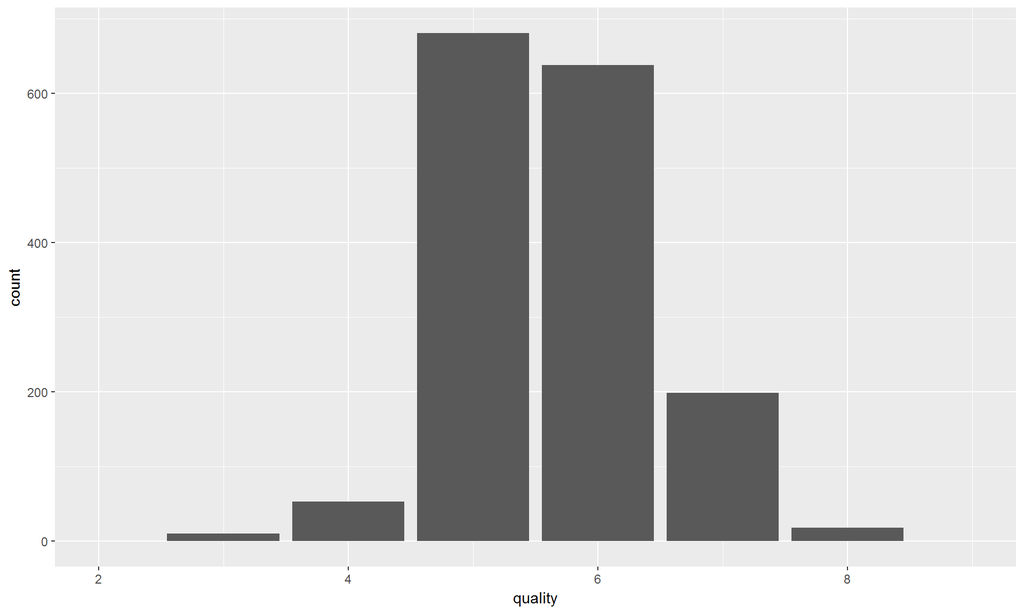

## 3.2 各种酸的分布

### fixed.acidity的分布

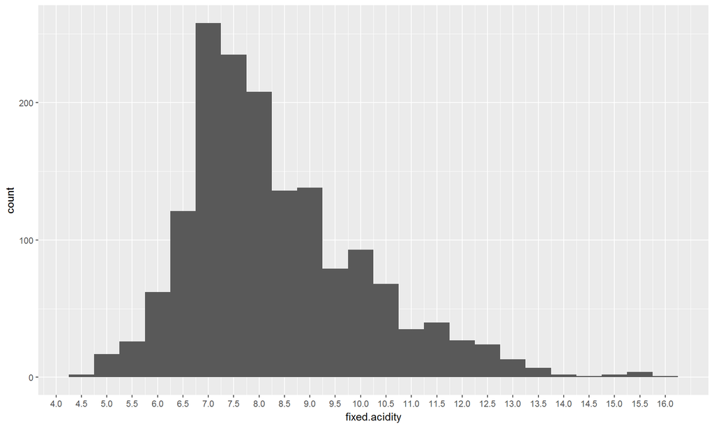

fixed.acidity呈现正偏态分布, 平均值等于8.32.

### volatile.acidity的分布

```
##    Min. 1st Qu.  Median    Mean 3rd Qu.    Max.
##  0.1200  0.3900  0.5200  0.5278  0.6400  1.5800
```

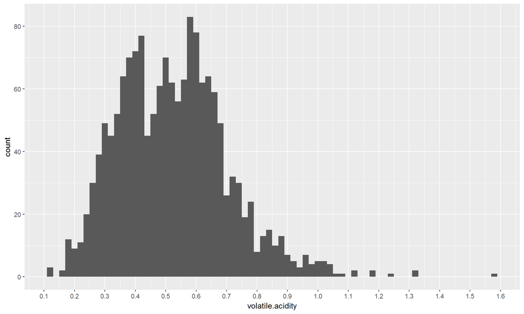

volatile.acidity有两个明显的峰，横坐标对应约为0.4和0.6，总的平均值等于0.53。

### citric.acid的分布

```
##    Min. 1st Qu.  Median    Mean 3rd Qu.    Max.
##   0.000   0.090   0.260   0.271   0.420   1.000
```

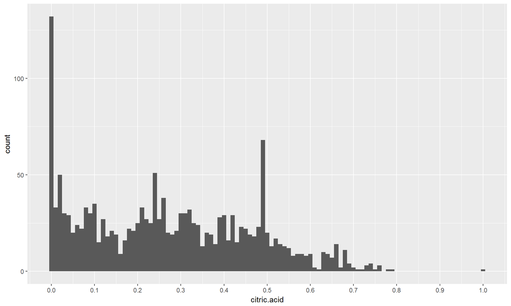

citric.acid的分布出现多个峰值，有几个特殊的值的计数比较多，噪声比较大，平均值等于0.27。与前面的fixed.acidity的含量相比，volatile.acidity和citric.acid含量低一个量级。这说明在红葡萄酒中，酒石酸占主要成分，挥发酸和柠檬酸属于添加剂成分。

### pH的分布

```
##    Min. 1st Qu.  Median    Mean 3rd Qu.    Max.
##   2.740   3.210   3.310   3.311   3.400   4.010
```

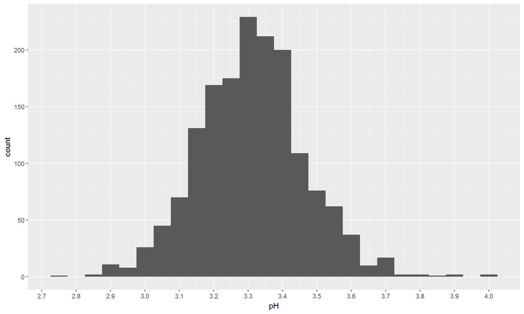

pH值呈现正态分布，在2.7-4.0之间，平均值为3.3。

## 3.3硫化物含量分布

### free.sulfur.dioxide分布

```
##    Min. 1st Qu.  Median    Mean 3rd Qu.    Max.
##    1.00    7.00   14.00   15.87   21.00   72.00
```

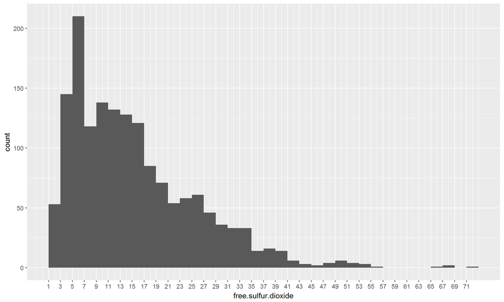

溶解性二氧化硫含量平均值是15.87，其中有较长的尾部数据。

### total.sulfur.dioxide分布

```
##    Min. 1st Qu.  Median    Mean 3rd Qu.    Max.
##    6.00   22.00   38.00   46.47   62.00  289.00
```

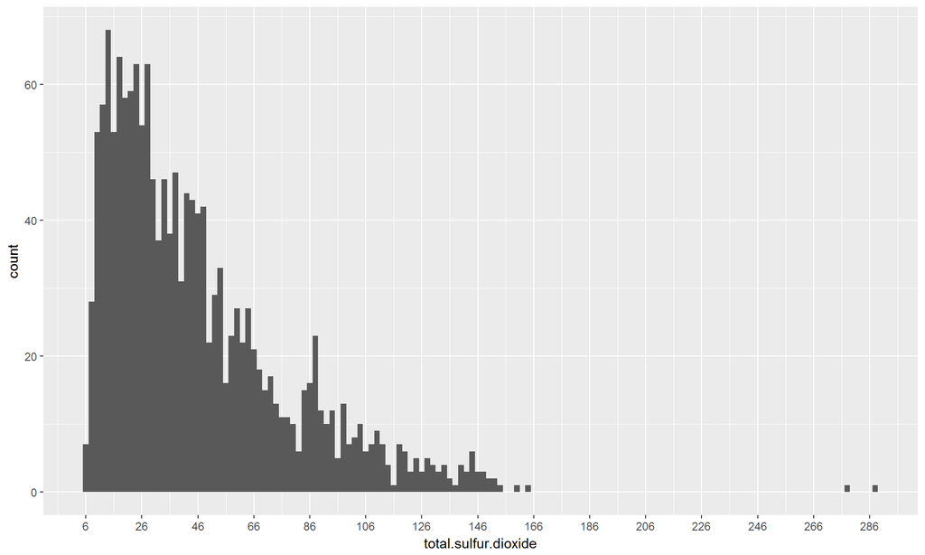

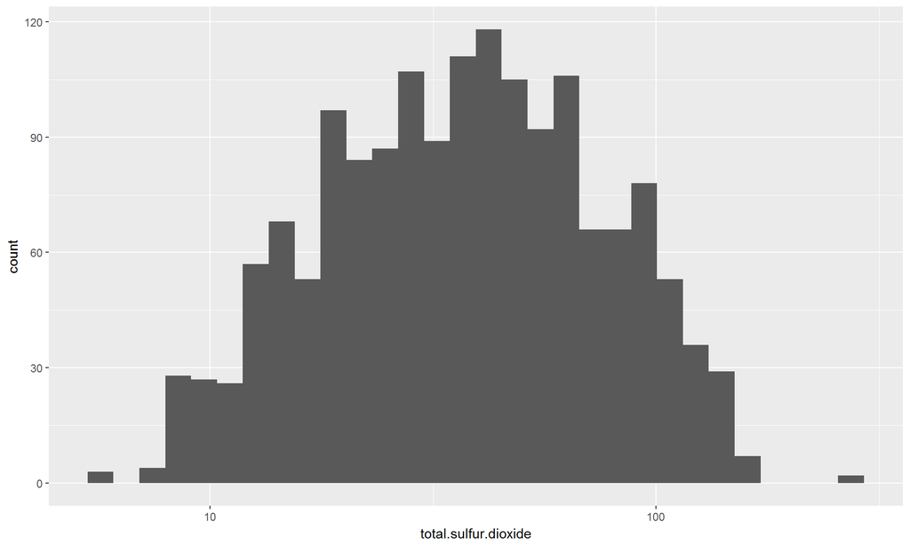

### sulphates分布

```
##    Min. 1st Qu.  Median    Mean 3rd Qu.    Max.
##  0.3300  0.5500  0.6200  0.6581  0.7300  2.0000
```

```
##  90%
## 0.85
```

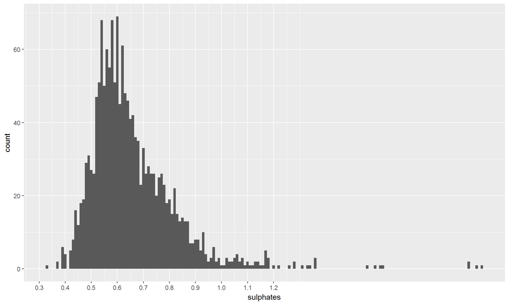

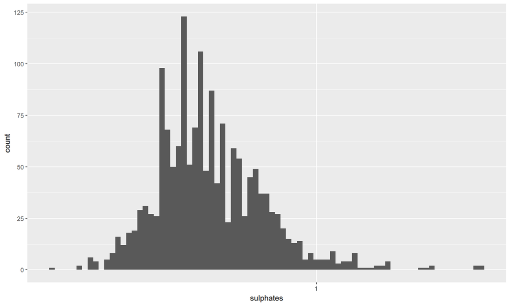

把横坐标取对数后，满足正态分布，平均值是0.66.

## 3.4糖residual.sugar、乙醇alcohol、密度density分布

### 糖residual.sugar分布

```
##    Min. 1st Qu.  Median    Mean 3rd Qu.    Max.
##   0.900   1.900   2.200   2.539   2.600  15.500
```

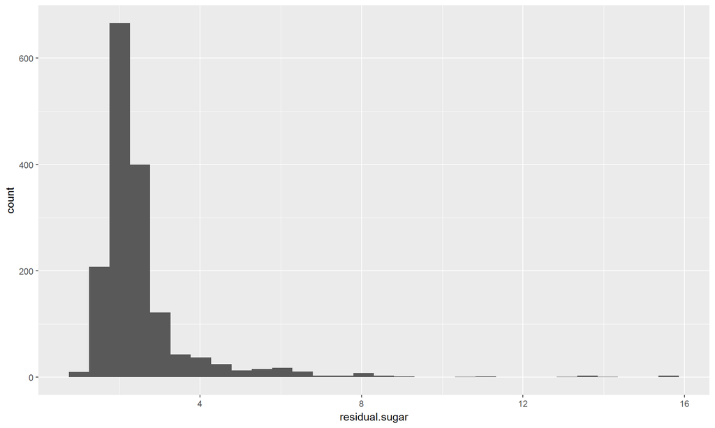

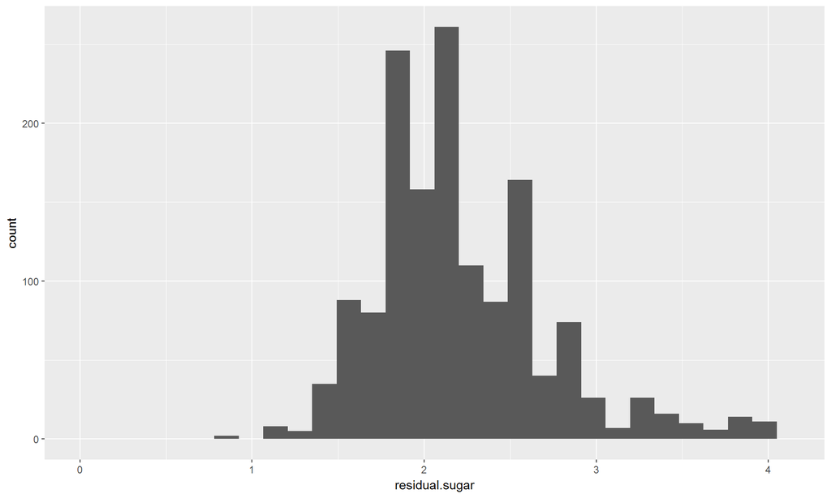

```
## [1] 0.4828814
```

```
## [1] 2.200991
```

糖类在(0,4)区间内满足正态分布，平均值2.2，方差0.48，在(4, 16)内有很长的尾巴。

### 乙醇alcohol分布

```
##    Min. 1st Qu.  Median    Mean 3rd Qu.    Max.
##    8.40    9.50   10.20   10.42   11.10   14.90
```

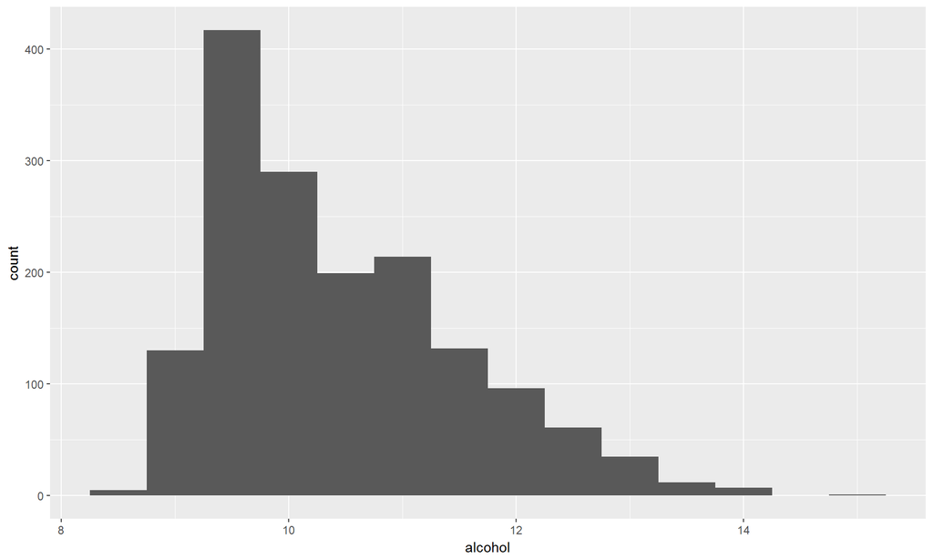

乙醇主要集中在8.4到15之间，平均值是10.4.

### 密度density分布

```
##    Min. 1st Qu.  Median    Mean 3rd Qu.    Max.
##  0.9901  0.9956  0.9968  0.9967  0.9978  1.0037
```

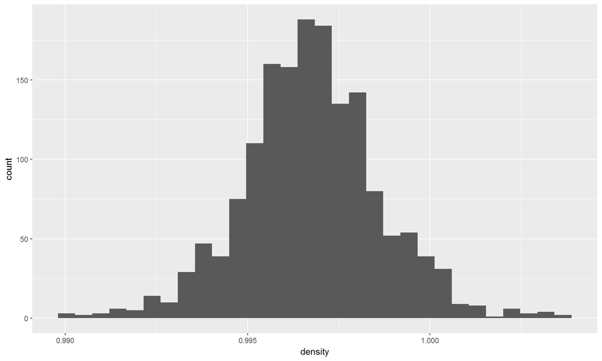

密度满足很好的正态分布，平均值0.997.

### 酸酒比acid_by_alcohol

品尝葡萄酒主要依靠味觉，而一般人对于酒精和酸的味道比较敏感，所以我构造出了一个新的变量**酸酒比acid_by_alcohol**，其中酸包含酒石酸、挥发性酸和柠檬酸的总和。

```
##    Min. 1st Qu.  Median    Mean 3rd Qu.    Max.
##  0.3800  0.7516  0.8621  0.8844  1.0014  1.8274
```

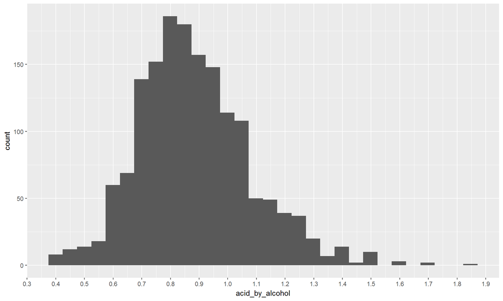

可以看到酸酒比acid_by_alcohol满足正态分布，平均值是0.88.

## 单变量分析小结

### **你的数据集结构是什么？**

本次项目使用的红酒数据集总共有1599个样本数据，12个特征，他们分别是：

#### **你的数据集有哪些有趣的特点？**

- quality与alcohol、volatile.acidity相关性最大，说明酒精度和醋酸对评分至关重要，酒精度数稍微高一点，醋酸成分少一些，红葡萄酒的评分更高。
- 影响pH值的主要是fixed.acidity，其次是citric.acid。

#### **还有哪些特点能够帮助你探究你感兴趣的特征？**

- 影响密度的主要是糖类residual.sugar（正相关）和酒精alcohol（负相关）。
- 溶解的$SO_{2}$free.sulfur.dioxide和总的亚硫酸根total.sulfur.dioxide有很强的正相关性，可以利用这点降维。

#### **你是否从已有特征中创造了新特征？**

是的，我构造了一个新变量：**酸酒比**。满足正态分布，在后面的两变量分析中将会考虑这个新特征与其他特征之间的关系。

#### **在你探究的特征中，有没有异常分布？你有没有采取什么措施来整理、调整或者改变数据的格式？如果有，说说理由。**

在单变量分析过程中，发现residual.sugar分布存在异常。该变量在（0，4）区间内基本满足正态分布，平均值是2.2，标准差是0.48，舍弃四个标准差意外的数据，因此在4.12处截断，舍弃在（4.12,16）的数据。

# 4 两变量画图

## 4.1相关性分析

先来看看各个变量之间的相关性。计算相关性系数矩阵，绘制热图。结果如下

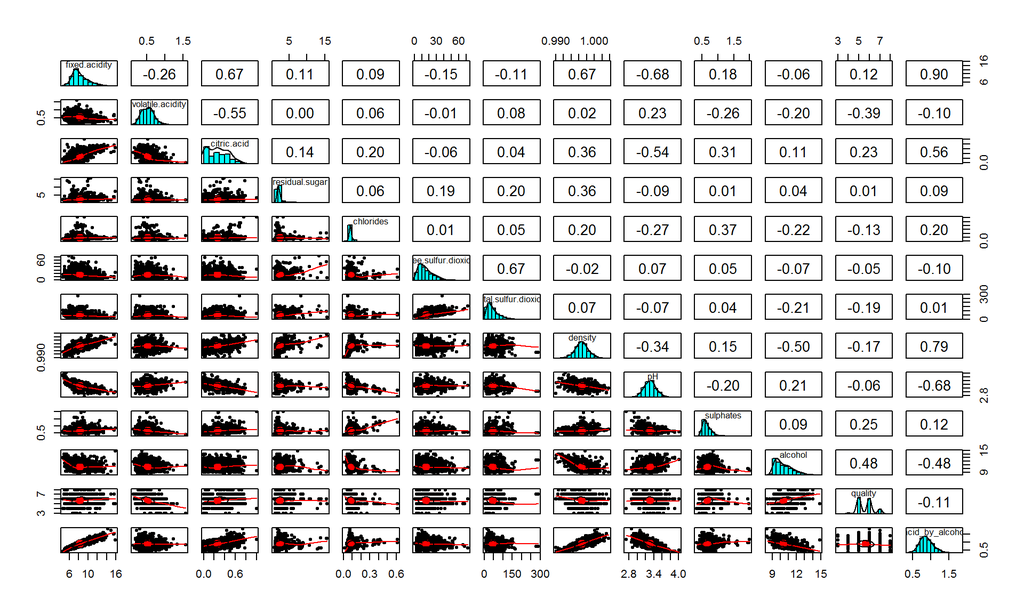

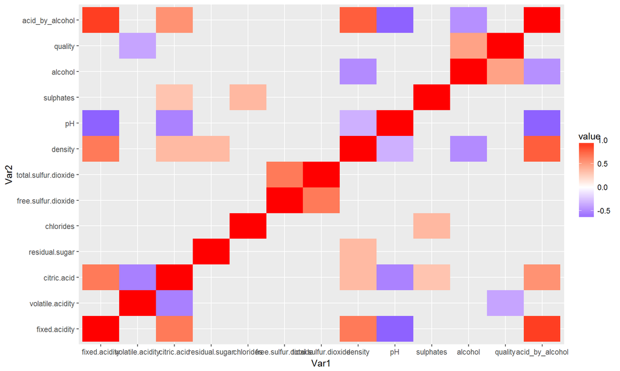

从图上可以看出几点：

1. 我们最关心的quality变量与alcohol和volatile.acidity相关性较强，与其他变量的直接相关性较弱，不足0.3.原因可能有几点：第一，quality与其他变量存在较强的非线性关系，但是相关系数并不能很好地表征这种关系；第二，quality确实与某一个单一变量关系不强，但是可能与某几个变量构造的新特征有很强的关系。所以后面我们需要把quality与其他变量逐一做二元变量分析，确定原因。
2. 有几个变量之间存在较强的相关性(大于0.3)。
- fixed.acidity 和 citric.acid、pH值
- volatile.acidity 和 citric.acid
- citric.acid 和 density、pH
- residual.sugar和density
- free.sulfur.dioxide和total.sulfur.dioxide
- chlorides和sulphates
- density和pH、alcohol
- acid_by_alcohol 和density

## 4.2 quality与alcohol、volatile.acidity

从相关系数矩阵可以看出，quality变量与alcohol和volatile.acidity相关性较强，先分析他们的关系。

### quality与alcohol

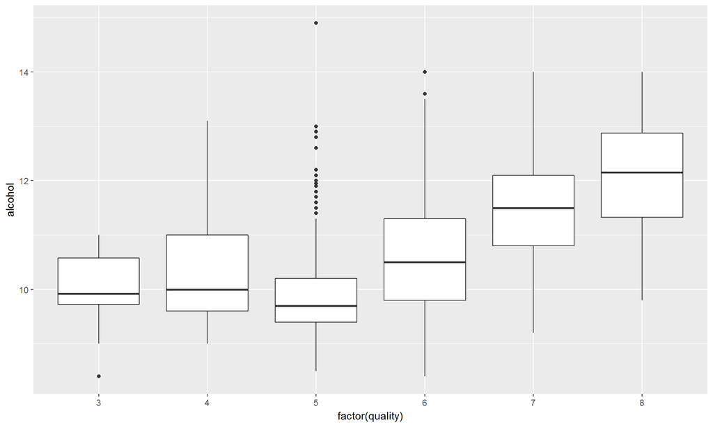

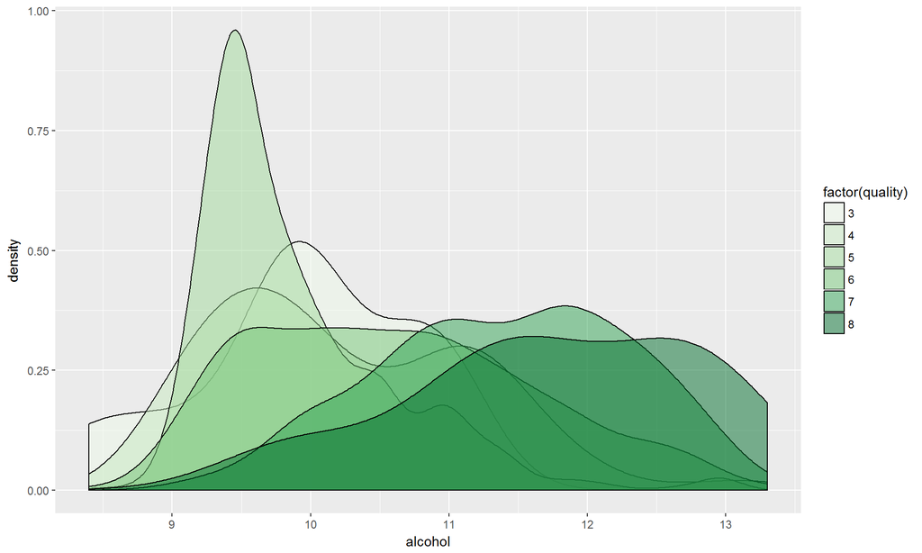

alcohol和quality呈正相关，当quality增大时，alcohol分布变宽。

### quality与volatile.acidity

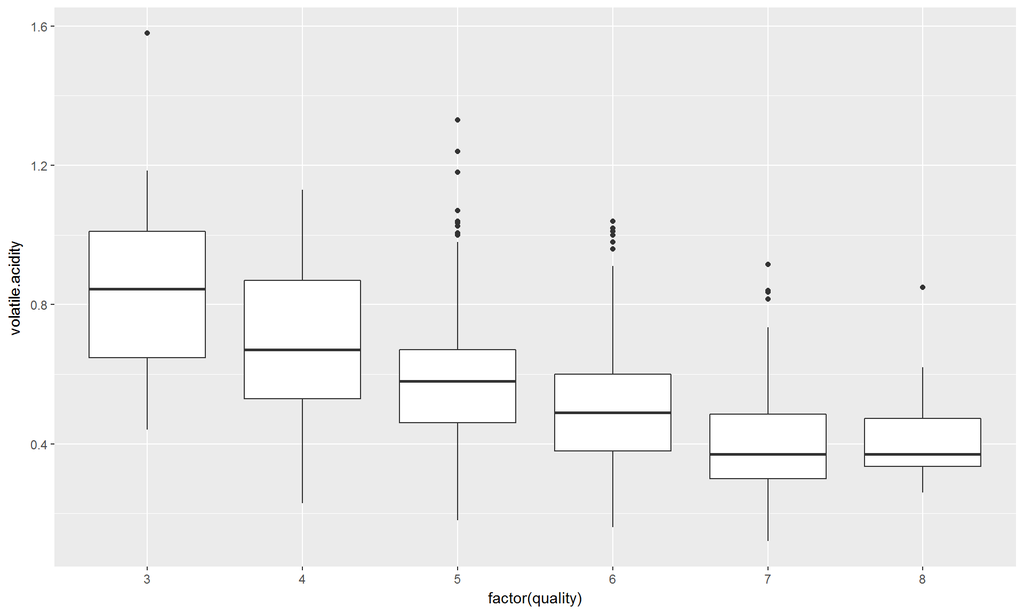

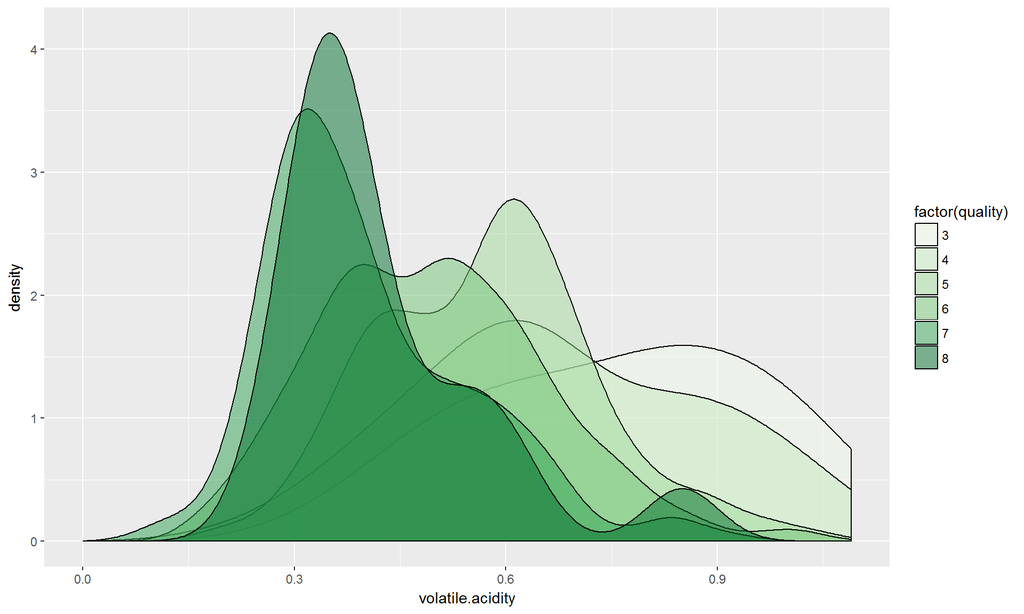

## 4.3 quality与剩下变量的关系

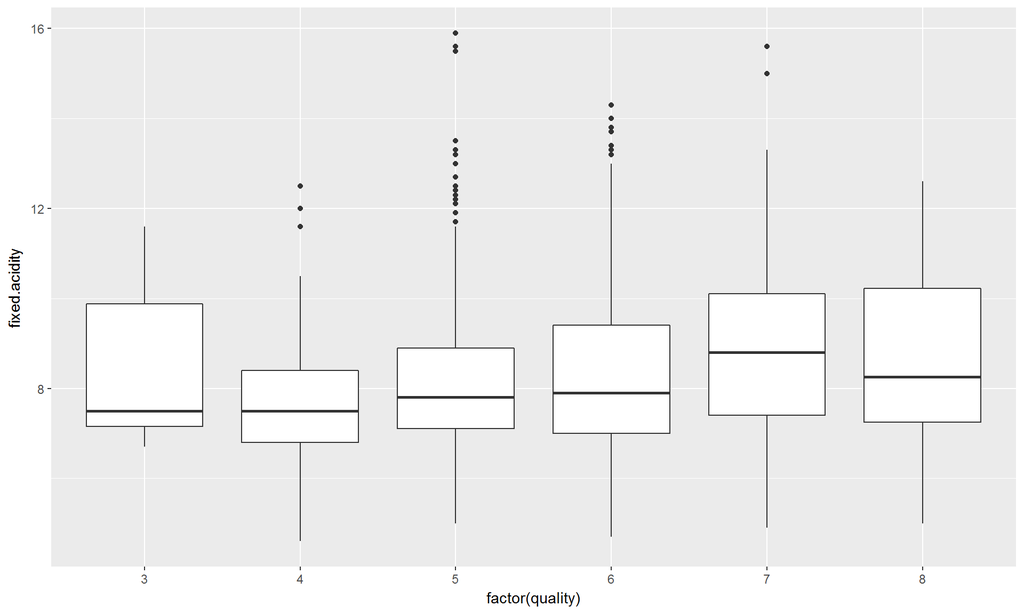

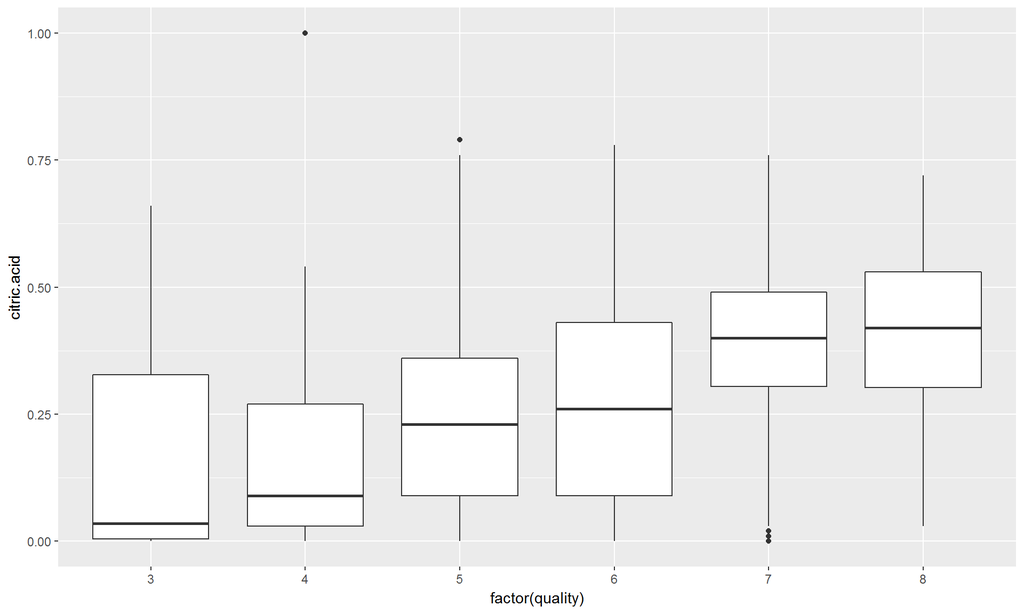

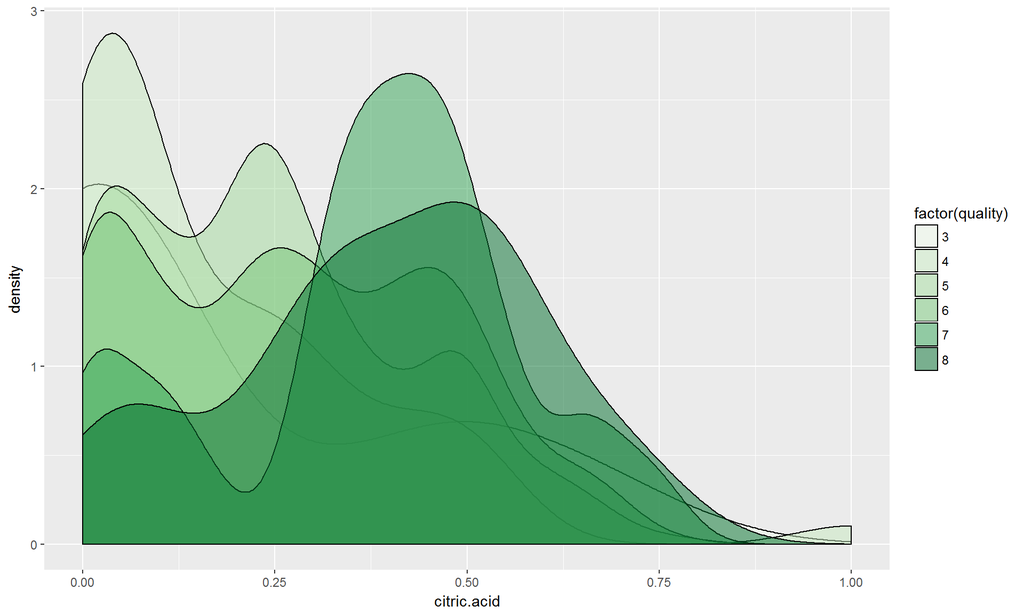

可以看出，citric.acid与quality之间呈阶跃型正相关关系。

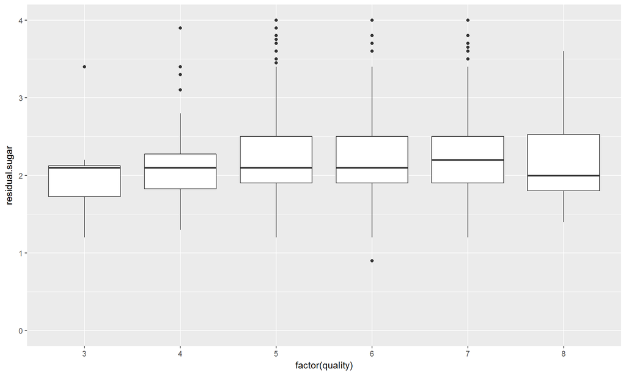

去除residual.sugar的异常值，发现与quality之间并没有明显的关系。

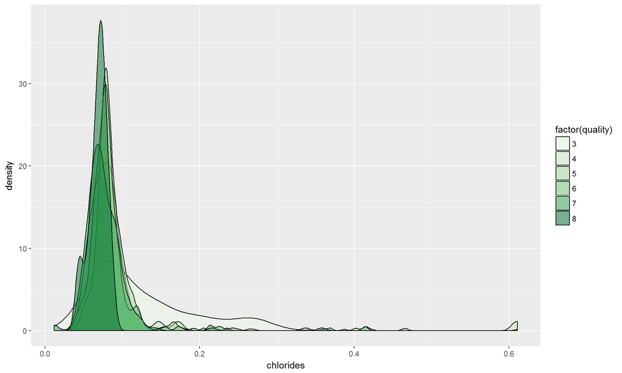

quality与chlorides之间也没有明显关系。

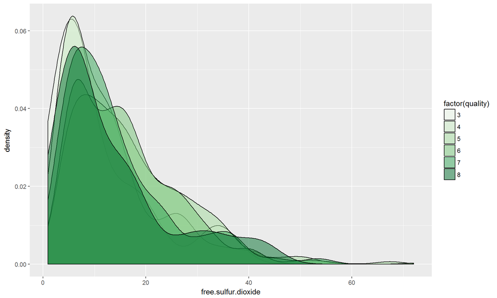